# Recipe for analysis of the dual-use data

Heidi Seibold

April 25, 2017

```r
knitr::opts_chunk$set(message = FALSE)
```

Dual-use goods are goods that can be used for civil and military purposes. In Switzerland, these goods are governed with a special legislation – unlike in other countries, where they are looked at as conventional arms exports.

The state secretariat for economic affairs (SECO) in Switzerland decides which dual-use goods may be exported and also provides the data after each quarter.

The SRF data team - the data journalism team of Swiss Radio and TV - has been repeatedly analysing this data in the past years. The reasons for using R for this task are various:

- R can read in Excel data (SECO provides the data in xlsx format)
- R allows for automation of data cleaning and analyses that have to be repeated
- R can export data to csv so it can be used in other programs (e.g. Excel)
- R produces good graphics and allows for individualised themes
- With R reproducible documents (e.g. HTML or PDF) can be created, changes are included without major efforts

You can find the entire analysis on the [SRF data GitHub repository](https://github.com/srfdata/2017-01-dual-use) and the article from January 2017 on the [SRF website](http://www.srf.ch/news/schweiz/schweiz-bewilligt-millionendeal-mit-dem-irak).

# Ask

At the beginning of 2017 SRF data analyst Timo Grossenbacher wanted to answer the question  
**Which dual-use goods were exported to which countries in each quarter of the years 2012 to 2016?**

Having cleaned and visualised the data he realised that suddenly in 2016 Switzerland started exporting dual-use goods to Irak after not having done so in the years prior. This became the story in the January 2017 [article](http://www.srf.ch/news/schweiz/schweiz-bewilligt-millionendeal-mit-dem-irak) .

We want to answer the same question and in order to have a clean project, create a new folder on your computer in which you will store all details on this project. We propose the following:

- Create a folder called `switzerland-dual-use`
- Within this folder create another two more folders called `data_raw` and `data_clean`

```
└── switzerland-dual-use
    ├── data_clean
    └── data_raw
```

# Find

The data can be found (in German) on the SECO website. SRF also keeps the data available in their [GitHub repo](https://github.com/srfdata/2017-01-dual-use/tree/master/analysis/input).

# Get

The data can be downloaded simply clicking on the data links on the SECO website. Get the data and store it in Folder `data_raw`.

Yor file structure should now look like this,

```
└── switzerland-dual-use
    ├── data_clean
    └── data_raw
        ├── 1_Quartal_2016_Bewilligungen.xlsx
        ├── 2. Quartal 2016 Erteilte Ausfuhrbewilligungen.xlsx
        ├── 3. Quartal 2016 Erteilte Ausfuhrbewilligungen.xlsx
        ├── 4. Quartal 2016 Erteilte Ausfuhrbewilligungen.xlsx
        ├── Stat_IP_2015_Bewilligungen.xlsx
        ├── Statistik Dual-Use 2014 Elic.xlsx
        ├── Statistik Dual-Use Jan. 2012 - Sep. 2014 Tracker.xlsx
        └── Statistik ML 2005-2013.xlsx
```

i.e. you should have the dual-use Excel files corresponding to years 2012 to 2016.

1. Open your R editor (e.g. RStudio)
2. Set your working directory to the `switzerland-dual-use` directory. To do this first enter

```r
getwd()
```

in the console. This will show your current working directory. E.g. for me it shows `[1] "/home/heidi/Documents"`. Next use `setwd()` to change to the correct diretory. For me it is `/home/heidi/Documents/switzerland-dual-use` and so I have to type

```r
setwd("switzerland-dual-use")
```

or equivalently

```r
setwd("/home/heidi/Documents/switzerland-dual-use")
```

To read Excel data into R, we need a specialised R package, which is called `readxl`. To install the package run

```r
install.packages("readxl")
```

To load the package run

```r
library("readxl")
```

```r
elic_2016_q1_raw <- read_excel(path = "data_raw/1_Quartal_2016_Bewilligungen.xlsx")
elic_2016_q2_raw <- read_excel(path = "data_raw/2. Quartal 2016 Erteilte Ausfuhrbewilligungen.xlsx")
elic_2016_q3_raw <- read_excel(path = "data_raw/3. Quartal 2016 Erteilte Ausfuhrbewilligungen.xlsx")
elic_2016_q4_raw <- read_excel(path = "data_raw/4. Quartal 2016 Erteilte Ausfuhrbewilligungen.xlsx")
```

# Verify

To check whether reading in worked and the data is what we wanted, there are a couple of useful commands in R. Let’s now first work with `elic_2016_q1_raw`:

- `names()` shows the collumn names of the data frame

```r
names(elic_2016_q1_raw)
```

```
## [1] "Geschäftsnummer"            "Bestimmungsland"
## [3] "Güterart"                   "Geschäftstyp"
## [5] "Richtung"                   "Exportkontrollnummer [EKN]"
## [7] "Wert [CHF]"                 ""
```

- `head()` shows the first few rows of the data frame

```r
head(elic_2016_q1_raw)
```

```
##   Geschäftsnummer Bestimmungsland                     Güterart
## 1         8007724         Ägypten               Dual Use Güter
## 2         8007844         Ägypten               Dual Use Güter
## 3         8007844         Ägypten               Dual Use Güter
## 4         8007844         Ägypten               Dual Use Güter
## 5         8006915         Ägypten               Dual Use Güter
## 6         8006792         Ägypten National kontrollierte Güter
##        Geschäftstyp Richtung Exportkontrollnummer [EKN] Wert [CHF]
## 1 Einzelbewilligung  Ausfuhr                    2B350.i      38330 NA
## 2 Einzelbewilligung  Ausfuhr                   5A002.a1       4546 NA
## 3 Einzelbewilligung  Ausfuhr                   5A002.a1     122287 NA
## 4 Einzelbewilligung  Ausfuhr                   5D002.c1       5000 NA
## 5 Einzelbewilligung  Ausfuhr                    2B350.i     132777 NA
## 6 Einzelbewilligung  Ausfuhr                        5.1        453 NA
```

- `tail()` shows the last few rows of the data frame

```r
tail(elic_2016_q1_raw)
```

```
##     Geschäftsnummer Bestimmungsland
## 938         8007295         Vietnam
## 939         8006715         Vietnam
## 940         8006715         Vietnam
## 941         8006361         Vietnam
## 942         8006361         Vietnam
## 943         8006361         Vietnam
##                                                         Güterart
## 938 Besondere militärische Güter\r\nBesondere militärische Güter
## 939                                                 Nukleargüter
## 940                                                 Nukleargüter
## 941                                               Dual Use Güter
## 942                                               Dual Use Güter
## 943                                               Dual Use Güter
##          Geschäftstyp Richtung Exportkontrollnummer [EKN] Wert [CHF]
## 938 Einzelbewilligung  Ausfuhr               ML13\r\nML22    5000000 NA
## 939 Einzelbewilligung  Ausfuhr                      0C003       2000 NA
## 940 Einzelbewilligung  Ausfuhr                      0C003      18000 NA
## 941 Einzelbewilligung  Ausfuhr                    5D001.a      16320 NA
## 942 Einzelbewilligung  Ausfuhr                   5A001.f1      10030 NA
## 943 Einzelbewilligung  Ausfuhr                    5D001.a       8330 NA
```

- `summary()` shows a summary of the data. For numeric variables such as the price (`Wert [CHF]`) it shows the [five number summary](https://en.wikipedia.org/wiki/Five-number_summary) and the mean (average). For character variables such as receiving country (`Bestimmungsland`) it shows the length and the information that it is a character variable.

```r
summary(elic_2016_q1_raw)
```

```
##  Geschäftsnummer   Bestimmungsland      Güterart
##  Min.   :8000360   Length:943         Length:943
##  1st Qu.:8006747   Class :character   Class :character
##  Median :8007211   Mode  :character   Mode  :character
##  Mean   :8007158
##  3rd Qu.:8007748
##  Max.   :8008218
##
##  Geschäftstyp         Richtung         Exportkontrollnummer [EKN]
##  Length:943         Length:943         Length:943
##  Class :character   Class :character   Class :character
##  Mode  :character   Mode  :character   Mode  :character
##
##
##
##
##    Wert [CHF]
##  Min.   :        0   Min.   : NA
##  1st Qu.:     1620   1st Qu.: NA
##  Median :    10500   Median : NA
##  Mean   :   422685   Mean   :NaN
##  3rd Qu.:   129224   3rd Qu.: NA
##  Max.   :120000000   Max.   : NA
##                      NA's   :943
```

- `str()` shows the type of each variable (here `num` for numeric and `chr` for character) and the first few values

```r
str(elic_2016_q1_raw)
```

```
## Classes 'tbl_df', 'tbl' and 'data.frame':    943 obs. of  8 variables:
##  $ Geschäftsnummer           : num  8007724 8007844 8007844 8007844 8006915 ...
##  $ Bestimmungsland           : chr  "Ägypten" "Ägypten" "Ägypten" "Ägypten" ...
##  $ Güterart                  : chr  "Dual Use Güter" "Dual Use Güter" "Dual Use Güter" "Dual Use Güter" ...
##  $ Geschäftstyp              : chr  "Einzelbewilligung" "Einzelbewilligung" "Einzelbewilligung" "Einzelbewilligung" ...
##  $ Richtung                  : chr  "Ausfuhr" "Ausfuhr" "Ausfuhr" "Ausfuhr" ...
##  $ Exportkontrollnummer [EKN]: chr  "2B350.i" "5A002.a1" "5A002.a1" "5D002.c1" ...
##  $ Wert [CHF]                : num  38330 4546 122287 5000 132777 ...
##  $                           : num  NA NA NA NA NA NA NA NA NA NA ...
```

# Clean

In this section we will need the `dplyr` package

```r
library("dplyr")   ## if not available install by typing install.packages("dplyr")
```

As a first step we want to combine the four 2016 data sets. You might have already realised that the first data set has one collumn that is just `NA`. `NA` is the missing value indicator in R. So basically this collumn does not contain any information. Let’s see what happens to this collumn if we combine the four data sets using function `bind_rows()`.

```r
names(elic_2016_q1_raw)
```

```
## [1] "Geschäftsnummer"            "Bestimmungsland"
## [3] "Güterart"                   "Geschäftstyp"
## [5] "Richtung"                   "Exportkontrollnummer [EKN]"
## [7] "Wert [CHF]"                 ""
```

```r
names(elic_2016_q2_raw)
```

```
## [1] "Geschäftsnummer"            "Bestimmungsland"
## [3] "Güterart"                   "Geschäftstyp"
## [5] "Richtung"                   "Exportkontrollnummer [EKN]"
## [7] "Wert [CHF]"
```

```r
elic_2016_1 <- bind_rows("16/01" = elic_2016_q1_raw,
                         "16/02" = elic_2016_q2_raw,
                         "16/03" = elic_2016_q3_raw,
                         "16/04" = elic_2016_q4_raw,
                         .id = "Quartal")

names(elic_2016_1)
```

```
## [1] "Quartal"                    "Geschäftsnummer"
## [3] "Bestimmungsland"            "Güterart"
## [5] "Geschäftstyp"               "Richtung"
## [7] "Exportkontrollnummer [EKN]" "Wert [CHF]"
## [9] ""
```

```r
str(elic_2016_1)
```

```
## Classes 'tbl_df', 'tbl' and 'data.frame':    3083 obs. of  9 variables:
##  $ Quartal                   : chr  "16/01" "16/01" "16/01" "16/01" ...
##  $ Geschäftsnummer           : num  8007724 8007844 8007844 8007844 8006915 ...
##  $ Bestimmungsland           : chr  "Ägypten" "Ägypten" "Ägypten" "Ägypten" ...
##  $ Güterart                  : chr  "Dual Use Güter" "Dual Use Güter" "Dual Use Güter" "Dual Use Güter" ...
##  $ Geschäftstyp              : chr  "Einzelbewilligung" "Einzelbewilligung" "Einzelbewilligung" "Einzelbewilligung" ...
##  $ Richtung                  : chr  "Ausfuhr" "Ausfuhr" "Ausfuhr" "Ausfuhr" ...
##  $ Exportkontrollnummer [EKN]: chr  "2B350.i" "5A002.a1" "5A002.a1" "5D002.c1" ...
##  $ Wert [CHF]                : num  38330 4546 122287 5000 132777 ...
##  $                           : num  NA NA NA NA NA NA NA NA NA NA ...
```

`bind_rows()` keeps all collumns in all data sets and fills them with `NA` for the data sets that do not contain this collumn. Also it created a new collumn called `Quartal`. It did that because we told it that the `.id` collumn is `Quartal` and the values for each `Quartal` is given in the quotation marks `"`.

Now we do not want to keep the collumn with just `NA` values and we want to rename a few variables. We can do this with function `select()`:

- To just select a variable, name it (e.g. `Quartal`)
- To select and rename a variable, put `newname = oldname` (e.g. `GN = Geschäftsnummer`)
- For variables with spaces or special symbols, use to show where it starts and ends (see e.g. `Wert [CHF]`)
- To select all except one variable, use the minus symbol (e.g. `select(.data = elic_2016_3, -Art)` below)

```r
elic_2016_2 <- select(.data = elic_2016_1,
                      GN = Geschäftsnummer,
                      Quartal,
                      Land = Bestimmungsland,
                      Wert = `Wert [CHF]`,
                      Typ = Güterart,
                      Signatur = `Exportkontrollnummer [EKN]`,
                      Art = Richtung)
str(elic_2016_2)
```

```
## Classes 'tbl_df', 'tbl' and 'data.frame':    3083 obs. of  7 variables:
##  $ GN      : num  8007724 8007844 8007844 8007844 8006915 ...
##  $ Quartal : chr  "16/01" "16/01" "16/01" "16/01" ...
##  $ Land    : chr  "Ägypten" "Ägypten" "Ägypten" "Ägypten" ...
##  $ Wert    : num  38330 4546 122287 5000 132777 ...
##  $ Typ     : chr  "Dual Use Güter" "Dual Use Güter" "Dual Use Güter" "Dual Use Güter" ...
##  $ Signatur: chr  "2B350.i" "5A002.a1" "5A002.a1" "5D002.c1" ...
##  $ Art     : chr  "Ausfuhr" "Ausfuhr" "Ausfuhr" "Ausfuhr" ...
```

We are only interested in exports (variable `Art`, value `"Ausfuhr"`), so we use `filter()` to select the rows in the data set where this is the case. Before that we check how many rows contain other values. `elic_2016_2$Art` gives us the variable we are interested in and functin `table()` creates a table for the frequencies of the different values.

```r
table(elic_2016_2$Art)
```

```
##
##     Ausfuhr     Einfuhr Vermittlung
##        3062           1          20
```

The data set after using `filter()` should have 3062 rows.

```r
elic_2016_3 <- filter(.data = elic_2016_2, Art == "Ausfuhr")
str(elic_2016_3)
```

```
## Classes 'tbl_df', 'tbl' and 'data.frame':    3062 obs. of  7 variables:
##  $ GN      : num  8007724 8007844 8007844 8007844 8006915 ...
##  $ Quartal : chr  "16/01" "16/01" "16/01" "16/01" ...
##  $ Land    : chr  "Ägypten" "Ägypten" "Ägypten" "Ägypten" ...
##  $ Wert    : num  38330 4546 122287 5000 132777 ...
##  $ Typ     : chr  "Dual Use Güter" "Dual Use Güter" "Dual Use Güter" "Dual Use Güter" ...
##  $ Signatur: chr  "2B350.i" "5A002.a1" "5A002.a1" "5D002.c1" ...
##  $ Art     : chr  "Ausfuhr" "Ausfuhr" "Ausfuhr" "Ausfuhr" ...
```

Now the collumn `Art` is not needed anymore. Let’s unselect it.

```r
elic_2016_4 <- select(.data = elic_2016_3, -Art)
str(elic_2016_4)
```

```
## Classes 'tbl_df', 'tbl' and 'data.frame':    3062 obs. of  6 variables:
##  $ GN      : num  8007724 8007844 8007844 8007844 8006915 ...
##  $ Quartal : chr  "16/01" "16/01" "16/01" "16/01" ...
##  $ Land    : chr  "Ägypten" "Ägypten" "Ägypten" "Ägypten" ...
##  $ Wert    : num  38330 4546 122287 5000 132777 ...
##  $ Typ     : chr  "Dual Use Güter" "Dual Use Güter" "Dual Use Güter" "Dual Use Güter" ...
##  $ Signatur: chr  "2B350.i" "5A002.a1" "5A002.a1" "5D002.c1" ...
```

It looks like the variable `Typ` needs a bit of cleaning:

```r
unique(elic_2016_4$Typ)
```

```
##  [1] "Dual Use Güter"
##  [2] "National kontrollierte Güter"
##  [3] "Nukleargüter"
##  [4] "Besondere militärische Güter"
##  [5] "Chemikalien CWÜ"
##  [6] "Dual Use Güter\r\nDual Use Güter"
##  [7] "Chemikalien CWÜ\r\nDual Use Güter"
##  [8] "Besondere militärische Güter\r\nBesondere militärische Güter"
##  [9] "Sanktionsgüter"
## [10] "Chemikalien CWÜ\r\nBesondere militärische Güter"
## [11] "Dual Use Güter\r\nChemikalien CWÜ"
```

```r
typ_from <- c("Chemikalien CWÜ",
              "Dual Use Güter\r\nDual Use Güter",
              "Chemikalien CWÜ\r\nDual Use Güter",
              "Besondere militärische Güter\r\nBesondere militärische Güter",
              "Chemikalien CWÜ\r\nBesondere militärische Güter",
              "Dual Use Güter\r\nChemikalien CWÜ")
typ_to <- c("Chemikalien",
            "Dual Use Güter",
            "Chemikalien",
            "Besondere militärische Güter",
            "Chemikalien",
            "Dual Use Güter")


change_charval <- function(x, from, to) {

  for(i in 1:length(from)) {
    x[x == from[i]] <- to[i]
  }

  return(x)
}

Typ <- change_charval(x = elic_2016_4$Typ, from = typ_from, to = typ_to)
elic_2016_4$Typ_raw <- elic_2016_4$Typ
elic_2016_4$Typ <- Typ
```

# Analyse

For this section we’ll produce some nice graphics with package `ggplot2`

```r
library("ggplot2")
```

Let’s try making a first plot, which shows how often Switzerland has exported to each country.

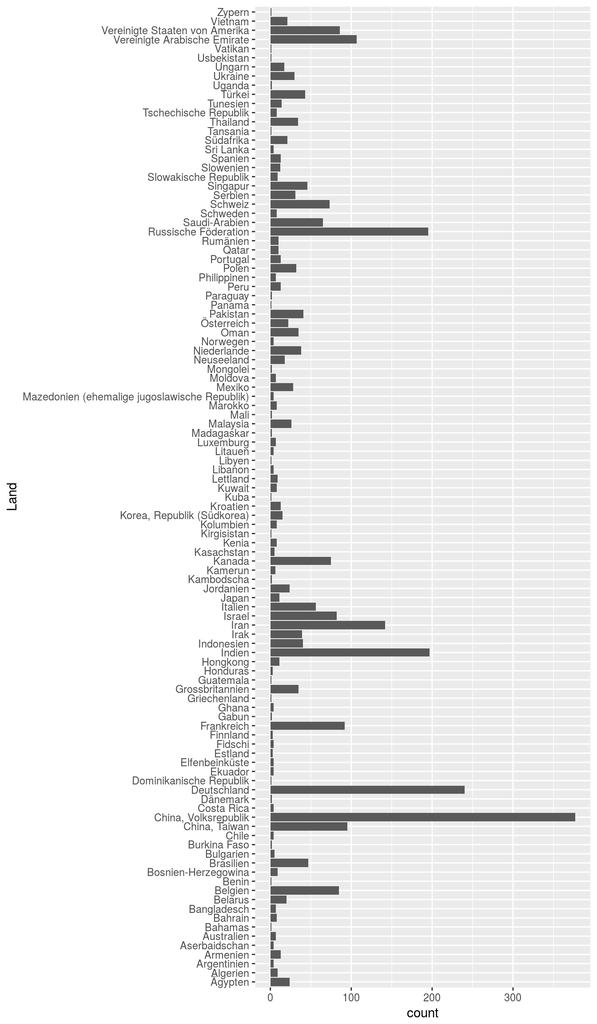

```r
# table(elic_2016_4$Land, useNA = "always")

ggplot(elic_2016_4, aes(x = Land)) +
  geom_bar() +
  coord_flip()
```

Let’s sort the country in the plot by number of exports to it. `summarize()` helps us computing the number of exports, `order()` helps us getting the correct order, and `factor()` helps us define that we want the country levels according to a fixed order. `ggplot()` automatically understands that it should plot the factor levels in the order given.

```r
n_land <- summarise(group_by(elic_2016_4, Land), n = NROW(Land))
ord <- order(n_land$n)
str(ord)
```

```
##  int [1:107] 7 12 23 32 34 50 54 58 75 94 ...
```

```r
ordered_land <- n_land$Land[ord]
str(ordered_land)
```

```
##  chr [1:107] "Bahamas" "Benin" "Dominikanische Republik" ...
```

```r
elic_2016_4$Land <- factor(elic_2016_4$Land, levels = ordered_land)
str(elic_2016_4$Land)
```

```
##  Factor w/ 107 levels "Bahamas","Benin",..: 76 76 76 76 76 76 76 76 76 54 ...
```

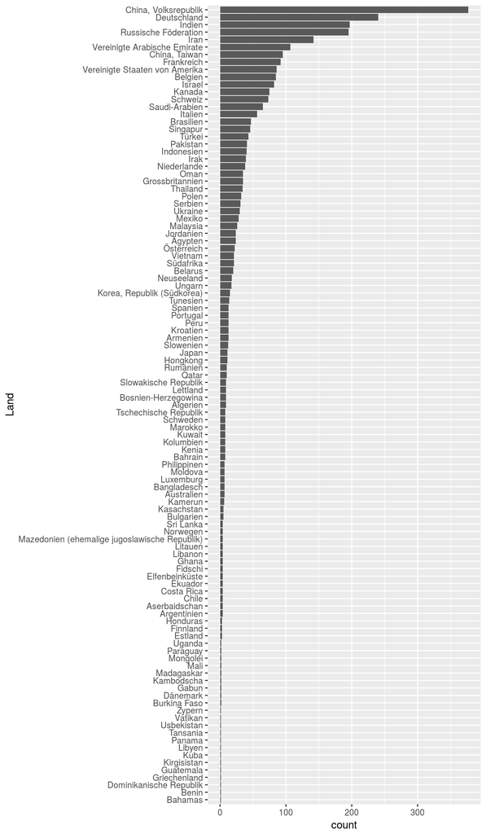

```r
ggplot(elic_2016_4, aes(x = Land)) +
  geom_bar() +
  coord_flip()
```

And now one, which shows how much worth the goods were that were exported to each country. Again we want to have that in a specific order.

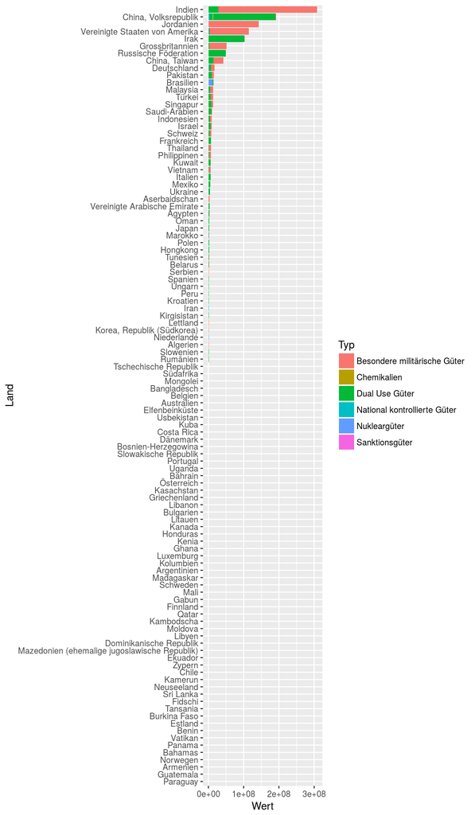

```r
wert_land <- summarise(group_by(elic_2016_4, Land), sum = sum(Wert))
ordered_land <- wert_land$Land[order(wert_land$sum)]
elic_2016_4$Land <- factor(elic_2016_4$Land, levels = ordered_land)

ggplot(elic_2016_4, aes(x = Land, y = Wert, fill = Typ)) +
  geom_bar(stat = "identity") +
  coord_flip()
```

But wait, why are there countries listed, that do not seem to have gotten anything from switzerland? Let’s look at those:

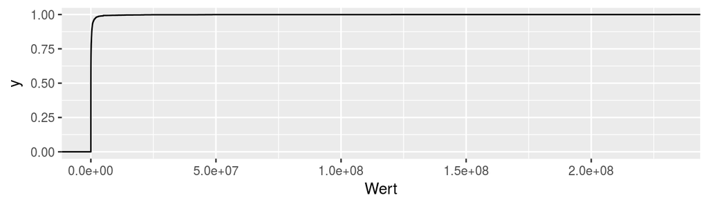

```r
p <- ggplot(elic_2016_4, aes(x = Wert)) + stat_ecdf()
p
```

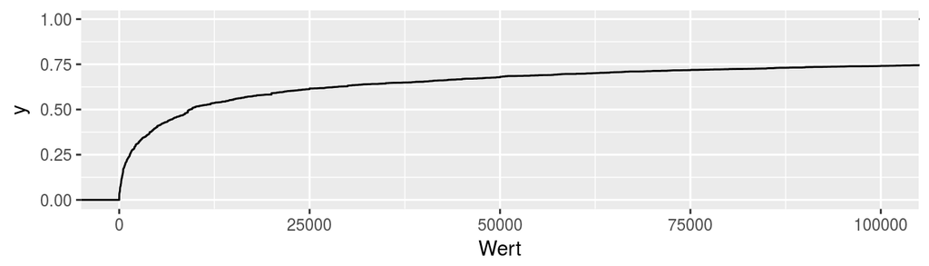

```r
p + coord_cartesian(xlim = c(0, 10^5))
```

```r
novalue  <- filter(.data = elic_2016_4, Wert == 0)
str(novalue)
```

```
## Classes 'tbl_df', 'tbl' and 'data.frame':    36 obs. of  7 variables:
##  $ GN      : num  8007783 8007783 8007690 8007690 8007085 ...
##  $ Quartal : chr  "16/01" "16/01" "16/01" "16/01" ...
##  $ Land    : Factor w/ 107 levels "Paraguay","Guatemala",..: 106 106 99 99 99 99 99 99 99 89 ...
##  $ Wert    : num  0 0 0 0 0 0 0 0 0 0 ...
##  $ Typ     : chr  "Dual Use Güter" "Dual Use Güter" "Besondere militärische Güter" "Besondere militärische Güter" ...
##  $ Signatur: chr  "5D001.a" "5D001.a" "ML13" "ML13" ...
##  $ Typ_raw : chr  "Dual Use Güter" "Dual Use Güter" "Besondere militärische Güter" "Besondere militärische Güter" ...
```

```r
elic_2016_value <- filter(.data = elic_2016_4, Wert > 0)
elic_2016_value$Land <- droplevels(elic_2016_value$Land)
```

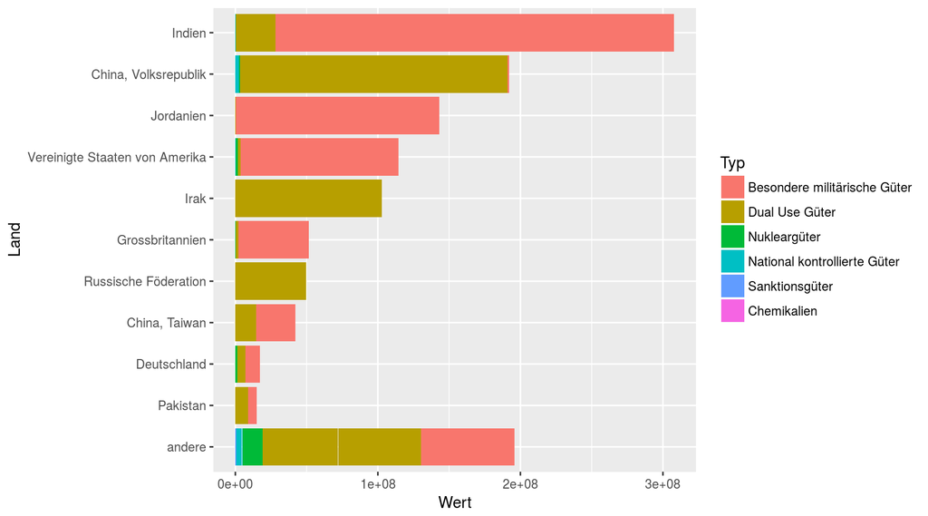

```r
elic_2016_4$Land2 <- elic_2016_4$Land
highest10 <- tail(levels(elic_2016_4$Land), 10)

levels(elic_2016_4$Land2)[!(levels(elic_2016_4$Land2) %in% highest10)] <- "andere"


wert_typ <- summarise(group_by(elic_2016_4, Typ), sum = sum(Wert))
ordered_typ <- wert_typ$Typ[order(wert_typ$sum)]
elic_2016_4$Typ <- factor(elic_2016_4$Typ, levels = rev(ordered_typ))

p_cntry <- ggplot(elic_2016_4, aes(x = Land2, y = Wert, fill = Typ)) +
  geom_bar(stat = "identity") +
  coord_flip() +
  xlab("Land")
p_cntry
```

The cool thing with `ggplot2` for a newsroom is that you can have different themes.

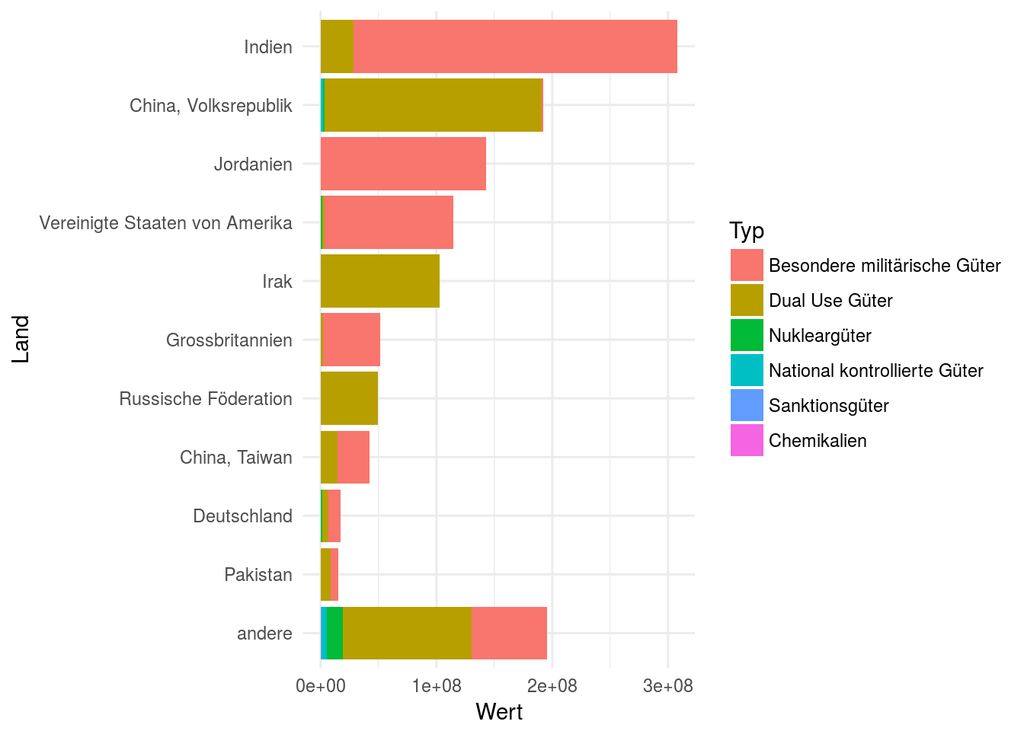

```r
p_cntry + theme_minimal()
```

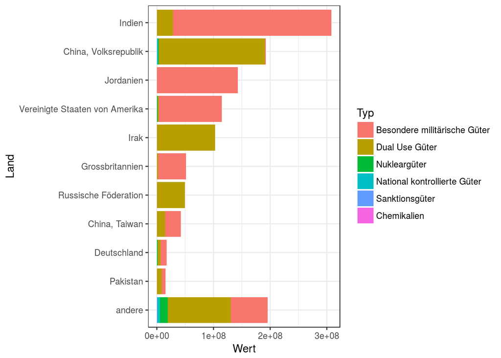

```r
p_cntry + theme_bw()
```

With the `ggthemes` package you can go even more wild and try themes that are similar to the themes of famous newsrooms…

```r
library("ggthemes")
```

…such as the Economist,…

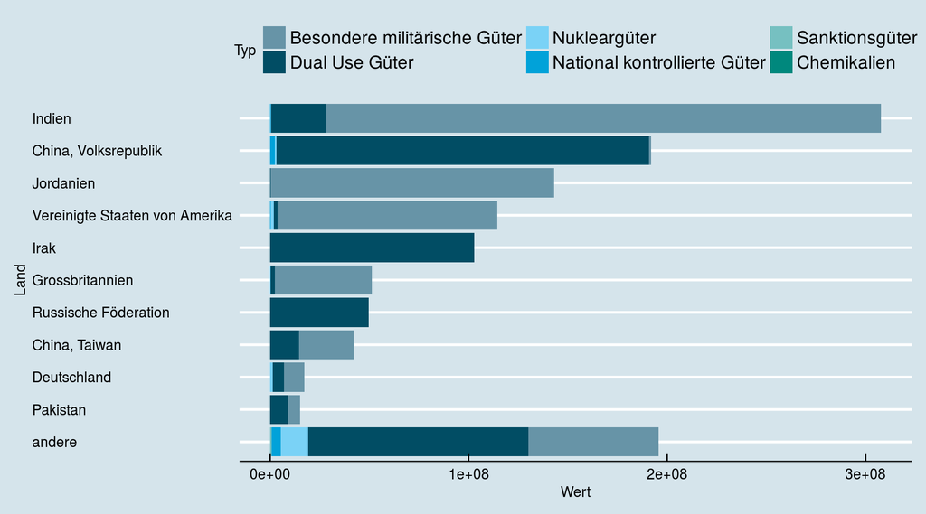

```r
p_cntry + theme_economist() + scale_fill_economist()
```

…FiveThirtyEight,…

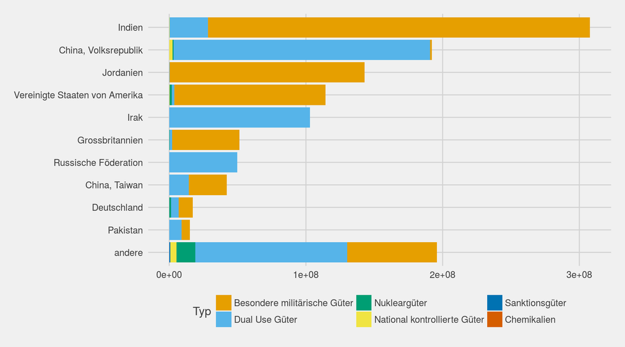

```r
my_palette <- c("#E69F00", "#56B4E9", "#009E73", "#F0E442", "#0072B2", "#D55E00")
p_cntry + theme_fivethirtyeight() + scale_fill_manual(values = my_palette)
```

…or the Wall Street Journal.

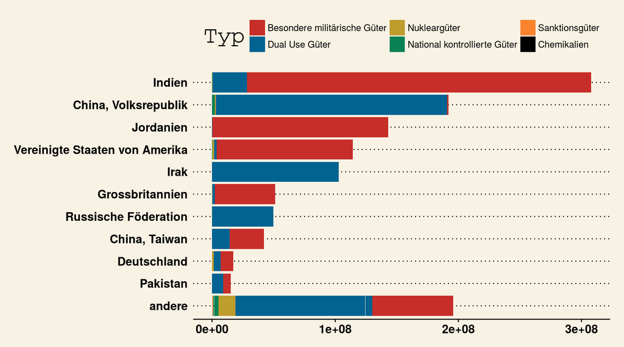

```r
p_cntry + theme_wsj() + scale_fill_wsj()
```

And if you want to really badly go back to an ungly 2003 Excel style, you can do that too :)

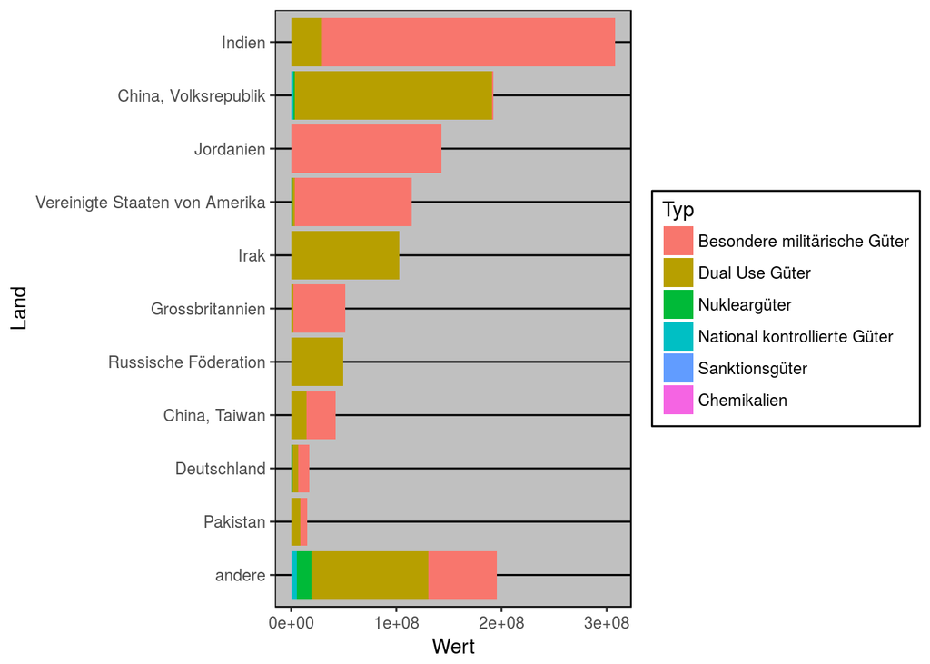

```r
p_cntry + theme_excel()
```

Or you take a theme you like and modify it. To create a School of Data themed plot you can use the following colors and fonts.

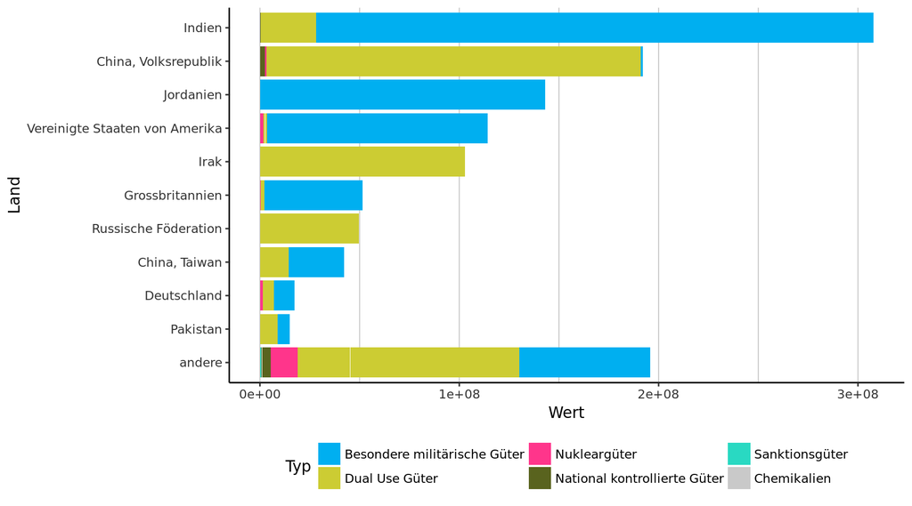

```r
scodablue <- "#00AFF0"
scodagrey <- "#333333"
scodagrey2 <- "#C9C9C9"
scodacol <- c(scodablue, "#CCCC33", "#FF358B", "#59631E", "#29D9C2", "#C9C9C9")
p_cntry + theme_classic(base_family = "Open Sans") +
  theme(axis.text = element_text(family = "Open Sans Bold", colour = scodagrey),
        panel.grid.major.x = element_line(color = scodagrey2),
        panel.grid.minor.x = element_line(color = scodagrey2),
        line = element_line(colour = scodagrey),
        legend.position = "bottom") +
  scale_fill_manual(values = scodacol)
```